# Unit IV (Ch. 7-10)

ECON 2106

## The Theory of the Firm

- This unit explores the theory of the firm.
- A firm (or producer or business) combines inputs — labor, capital, land, and materials — to produce outputs.
  - If the firm is successful, the outputs are **more valuable** than the inputs.

## Determinants of Firm Behavior

- The answers to key production questions depend on both production and cost conditions and on the **market structure** of the industry.
- Market structure refers to how competitive an industry is and can be described by questions such as:
  - How much **market power** does each firm possess?
  - How similar are products across firms?
  - How difficult is it for new firms to enter the industry?
  - Do firms compete primarily on price, advertising, or other product differences?

## Spectrum of Competition

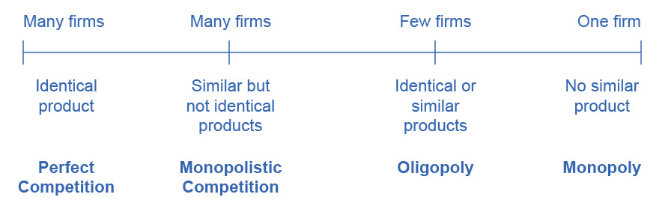

## Range in Size of U.S. Firms

### Source: U.S. Census, 2010

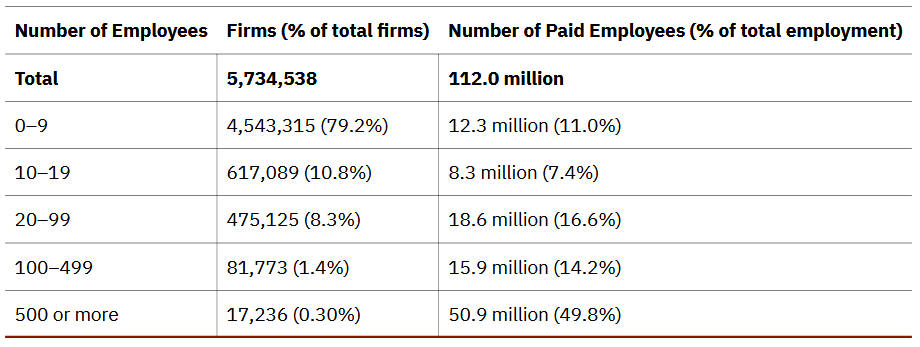

## Profit and Cost Basics

- Each business, regardless of size or complexity, tries to earn a **profit**:
  - $\pi = \text{Revenue} - \text{Costs}$
  - $\text{Revenue} = TR = P \times Q = \text{Price} \times \text{Quantity}$
  - $\text{Costs} = TC = FC + VC + OC = \text{Fixed} + \text{Variable} + \text{Opp.}$

## Explicit vs. Implicit Costs

- **Explicit costs** are out-of-pocket expenses made by the firm.
  - Examples include **wages** paid to employees or **rent** for office space.
- **Implicit costs** represent the **opportunity cost** of using resources the firm already owns.
  - Examples include working in the business without a formal salary, or using part of a home as retail space.
  - Implicit costs also include **depreciation** of equipment and materials necessary for production.

## Fixed and Variable Inputs

- **Fixed inputs** are those that cannot easily be changed in the short run.
  - For example, a **building** is a fixed input — the owner is bound by the lease until it expires.
- **Variable inputs** can be increased or decreased easily in the short run.
  - For instance, a pizzeria can order more ingredients or hire another worker with little delay.

## Time Horizons

- The **short run** is the period during which at least one factor of production is **fixed**.
  - During a lease, the pizza shop operates in the short run because it cannot change its building size.
- The **long run** is the period during which **all factors** are **variable**.
  - Once the lease expires, the owner can relocate to a larger or smaller space.

## Accounting vs. Economic Profit

- **Accounting profit** is a cash-based measure:
  - Total revenue minus **explicit costs** — the difference between money received and money paid out.
- **Economic profit** equals total revenue minus **total cost**, including both **explicit** and **implicit** costs.
  - This distinction matters because firms pay taxes (and dividends) on accounting profit, but the efficiency of decisions depends on economic profit.

## Accounting vs. Economic Profit Example

- Eryn currently works for a corporate law firm where she makes $125k and is considering opening her own legal practice.
  - She expects to earn $200k per year once she establishes herself.
  - To run her own firm, she would need an office and a law clerk.
  - Office rent: $50k/year; law clerk: $35k/year
- Accounting $\pi = \text{TR} - \text{EC} = \$200 - (\$50k + \$35k) = \$115k$
- Economic $\pi = \text{TR} - \text{EC} - \text{OC} = \$200 - (\$50k + \$35k) - \$125k = -\$10k$

## Production Functions

- Recall our factors of production are: $Q(N,L,K,E) = f(N,L,K,E)$
- Often times, we simplify the production function such that $Q(K,L)$
- The marginal product of labor (capital) measures how much additional output one more worker (piece of technology) would increase a firm’s output, holding all else constant.
  - $MP_L = \frac{\partial Q(K,L)}{\partial L} \approx \frac{\Delta Q}{\Delta L}$

## Production Schedule: Example

| Lumberjacks | Trees | $MP_L$ |
| --- | --- | --- |
| 1 | 4 |  |
| 2 | 10 |  |
| 3 | 12 |  |
| 4 | 13 |  |
| 5 | 13 |  |

## Production Schedule: Example

| Lumberjacks | Trees | $MP_L$ |
| --- | --- | --- |
| 1 | 4 | 4 |
| 2 | 10 | 6 |
| 3 | 12 | 2 |
| 4 | 13 | 1 |
| 5 | 13 | 0 |

## Production Schedule: Example

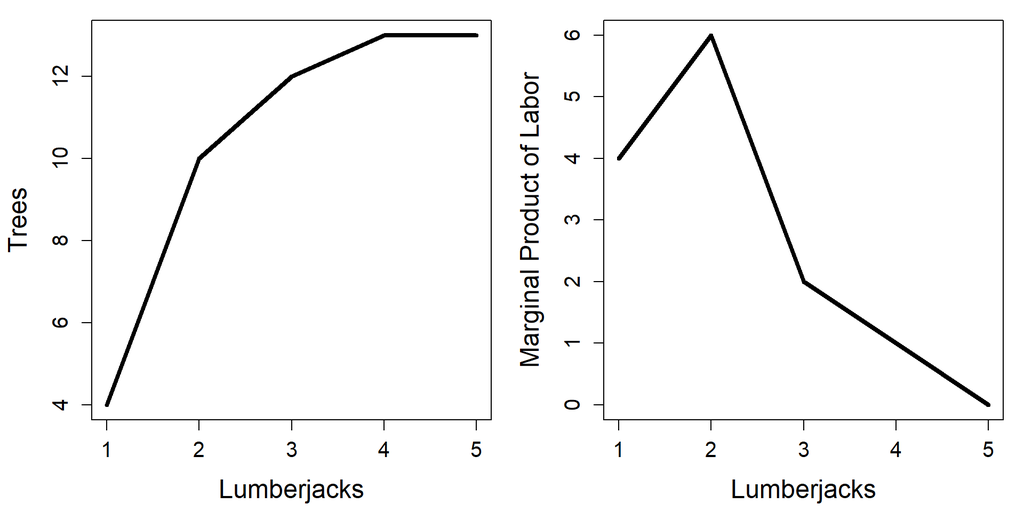

## The Law of Diminishing Marginal Product

- As more workers are added, **marginal product** may increase at first — due to specialization or efficiency gains — but eventually **decreases** as inputs become crowded or less productive.
  - In some cases, adding more workers may have **no effect** or even a **negative effect** on total output.
- This pattern is known as the **Law of Diminishing Marginal Product**, a key feature of **short-run production**.
  - The idea parallels **diminishing marginal utility** in consumer theory.

## Cost Relationships

- $\text{Average Cost} = \dfrac{TC}{Q} = \dfrac{VC + FC}{Q}$
- $\text{Marginal Cost} = \dfrac{\Delta TC}{\Delta Q} = \dfrac{\Delta VC + \Delta FC}{\Delta Q} = \dfrac{\Delta VC}{\Delta Q} = \dfrac{VC_2 - VC_1}{Q_2 - Q_1}$

## Cost Curve Example

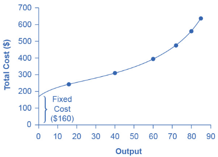

## Cost Schedule Example

```r
z <- data.frame(
  labor = 0:7,
  quantity = c(0, 16, 40, 60, 72, 80, 84, 82),
  fixed_cost = 160,
  variable_cost = 0:7 * 80
)
z$total_cost <- z$fixed_cost + z$variable_cost
z
```

```
  labor quantity fixed_cost variable_cost total_cost
1     0        0        160             0        160
2     1       16        160            80        240
3     2       40        160           160        320
4     3       60        160           240        400
5     4       72        160           320        480
6     5       80        160           400        560
7     6       84        160           480        640
8     7       82        160           560        720
```

## Cost Schedule Example

```r
z$average_cost <- z$total_cost / z$quantity
z$marginal_cost <- NA
z$marginal_cost[2:nrow(z)] <- diff(z$total_cost) / diff(z$quantity)
z
```

```
  labor quantity fixed_cost variable_cost total_cost average_cost marginal_cost
1     0        0        160             0        160          Inf            NA
2     1       16        160            80        240    15.000000      5.000000
3     2       40        160           160        320     8.000000      3.333333
4     3       60        160           240        400     6.666667      4.000000
5     4       72        160           320        480     6.666667      6.666667
6     5       80        160           400        560     7.000000     10.000000
7     6       84        160           480        640     7.619048     20.000000
8     7       82        160           560        720     8.780488    -40.000000
```

## Cost Curves Example

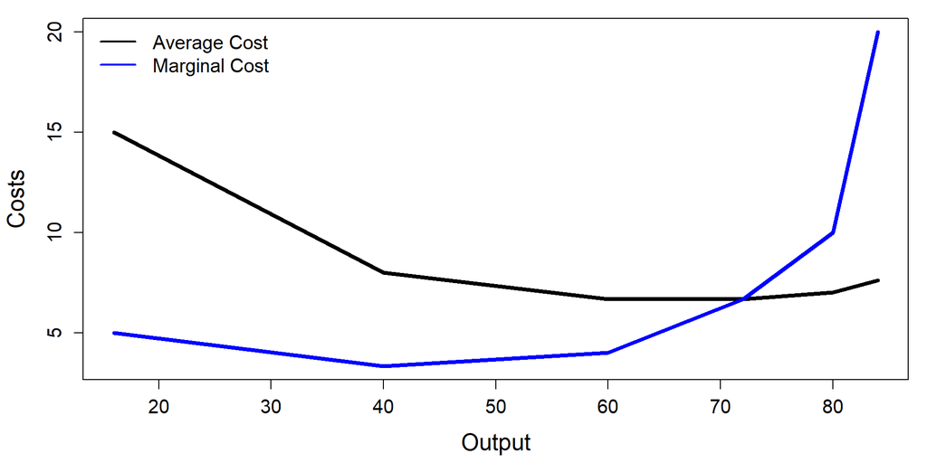

## Cost Schedule Example

### Change in cost per worker

```r
z$average_cost <- z$total_cost / z$labor
z$marginal_cost <- NA
z$marginal_cost[2:nrow(z)] <- diff(z$total_cost) / diff(z$labor)
z
```

```
  labor quantity fixed_cost variable_cost total_cost average_cost marginal_cost
1     0        0        160             0        160          Inf            NA
2     1       16        160            80        240     240.0000            80
3     2       40        160           160        320     160.0000            80
4     3       60        160           240        400     133.3333            80
5     4       72        160           320        480     120.0000            80
6     5       80        160           400        560     112.0000            80
7     6       84        160           480        640     106.6667            80
8     7       82        160           560        720     102.8571            80
```

## Cost Curves Example

### Change in cost per worker

[figure not shown]

## Output Schedule Example

```r
## made up data, workers and a production function
z <- data.frame(l = 1:100)
z$q <- 2*log(z$l + 4) + 2*log(max(z$l)) + 1 - 2*log(max(z$l) + 4)
z <- rbind(data.frame(l = 0, q = 0), z)

# marginal product of labor
z$mp_l <- NA
z$mp_l[2:nrow(z)] <- diff(z$q) / diff(z$l)

head(round(z, 1))
```

```
  l   q mp_l
1 0 0.0   NA
2 1 4.1  4.1
3 2 4.5  0.4
4 3 4.8  0.3
5 4 5.1  0.3
6 5 5.3  0.2
```

## Output Curves Example

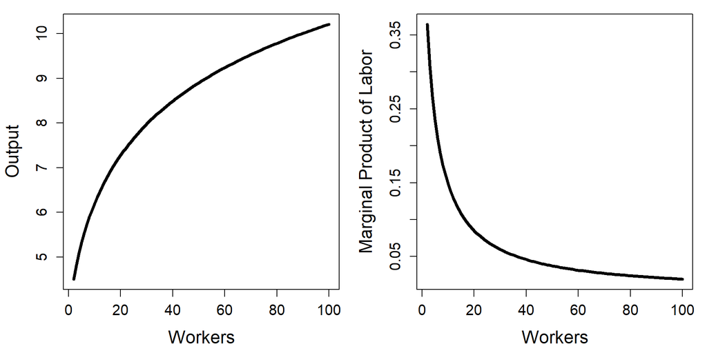

## Output Schedule Example

```r
# costs (variable + fixed)
wage <- 10
z$total_cost <- z$l * wage + 1000
z$average_cost <- z$total_cost / z$q

# Marginal cost via discrete differences
z$marginal_cost <- z$total_cost / z$q
z$marginal_cost[2:nrow(z)] <- diff(z$total_cost) / diff(z$q)

## peak at the data
head(round(z, 1))
```

```
  l   q mp_l total_cost average_cost marginal_cost
1 0 0.0   NA       1000          Inf           Inf
2 1 4.1  4.1       1010        243.9           2.4
3 2 4.5  0.4       1020        226.4          27.4
4 3 4.8  0.3       1030        214.0          32.4
5 4 5.1  0.3       1040        204.7          37.4
6 5 5.3  0.2       1050        197.5          42.5
```

## Cost Curves Example #2

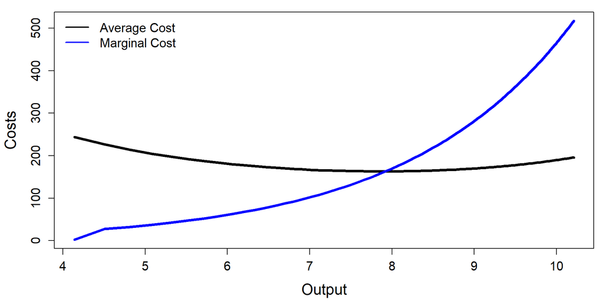

## Output Schedule Example

### Change in cost per worker

```r
# costs (variable + fixed)
wage <- 10
z$total_cost <- z$l * wage + 1000
z$average_cost <- z$total_cost / z$l

# Marginal cost via discrete differences
z$marginal_cost <- z$total_cost / z$l
z$marginal_cost[2:nrow(z)] <- diff(z$total_cost) / diff(z$l)

## peak at the data
head(round(z, 1))
```

```
  l   q mp_l total_cost average_cost marginal_cost
1 0 0.0   NA       1000          Inf           Inf
2 1 4.1  4.1       1010       1010.0            10
3 2 4.5  0.4       1020        510.0            10
4 3 4.8  0.3       1030        343.3            10
5 4 5.1  0.3       1040        260.0            10
6 5 5.3  0.2       1050        210.0            10
```

## Cost Curves Example #2

### Change in cost per worker

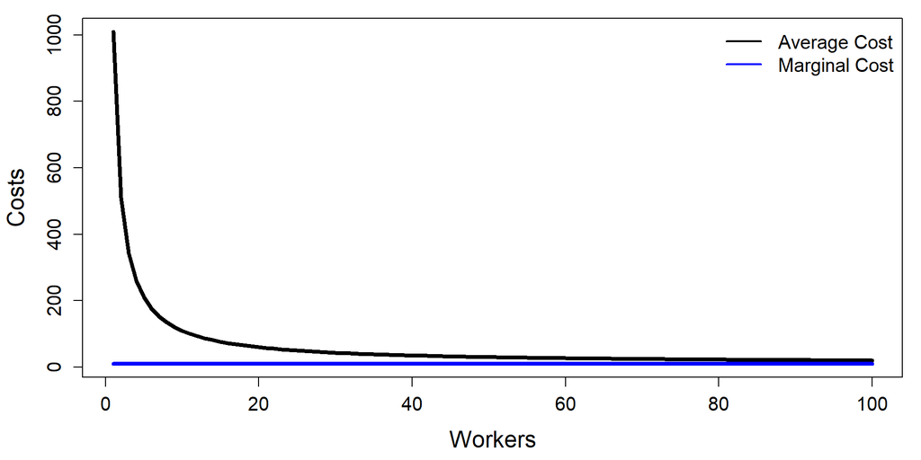

## Profit Margin

- $\text{Average } \pi = \dfrac{\pi}{Q} = \dfrac{TR - TC}{Q} = \dfrac{TR}{Q} - \dfrac{TC}{Q}=...$
- $...=\dfrac{TR}{Q} - \dfrac{TC}{Q} = \dfrac{P \times Q}{Q} - \dfrac{AC \times Q}{Q} = P - AC$
- $\text{Average } \pi = P - AC$
- Average profit is also known as the **profit margin** or profit per unit
  - If $P > AV$, then the firm is profitable
  - If $P > MC$, then increasing production will increase profits

## Production in the Long Run

- The **long run** refers to a time horizon in which the firm has **no fixed inputs** — all factors of production can be adjusted.
  - In contrast, in the short run, **capital** is typically treated as **fixed**, while **labor** is variable.
- The long run is **not a specific length of time**; it depends on the nature of the firm.
  - For example, if a firm has a **one-year lease** on its factory, then the long run begins **after that lease expires**, since the firm can now change its facility.
  - In the long run, a firm can **build new factories**, **purchase new machinery**, or **close existing facilities**.

## Production in the Long Run

|  | **Short-Run ($k = 1$)** |  | **Long-Run ($k = 3$)** |  |
| --- | --- | --- | --- | --- |
| Labor ($L$) | Output ($Q$) | $MP_L$ | Output ($Q$) | $MP_L$ |
| 1 | 5 | 5 | 5 | 5 |
| 2 | 6 | 1 | 10 | 5 |
| 3 | 8 | 2 | 15 | 5 |
| 4 | 8 | 0 | 17 | 2 |
| 5 | 8 | 0 | 18 | 1 |

## Production in the Long Run

- In planning for the long run, a firm compares **alternative production technologies** (or processes).
- **Technology** refers to all possible methods of combining inputs to produce outputs — it does **not necessarily mean** a new invention.
- Firms are assumed to seek the **lowest-cost technology** capable of producing a desired level of output.

## Choice of Production Technology

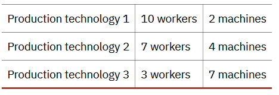

## Choice of Production Technology

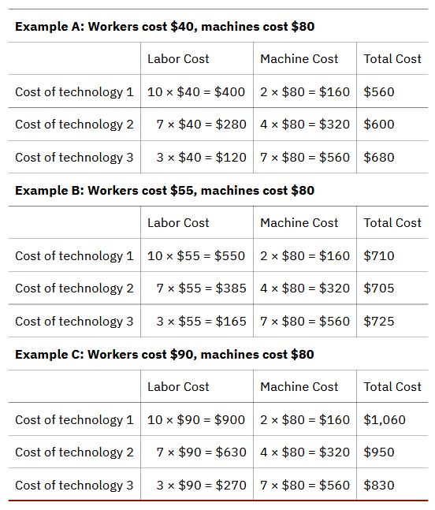

## Costs in the Long Run

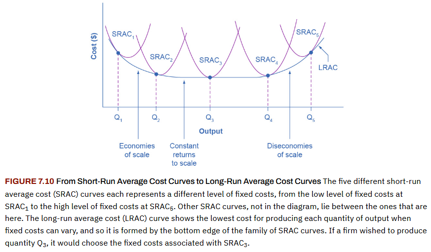

## Introduction to Perfect Competition

- Did you ever babysit, deliver newspapers, or mow lawns for money?
  - If so, you probably faced **many competitors offering identical services**.
  - There was nothing preventing others from entering the market, and most of you charged the **going rate**.
  - If you tried to charge more, customers could simply turn to someone else.

## Introduction to Perfect Competition

- A **perfectly competitive market** is an idealized case—but some industries come close.
- Firms in these markets face many competitors selling nearly identical goods and must act as **price takers**.
- Economists often use **agricultural markets** as a classic example.

## Perfect Competition

### Core Idea

- A perfectly competitive firm is a **price taker** because intense competition forces it to accept the **market equilibrium price**.
  - If a firm raises its price even slightly, it will lose all sales to competitors.
- The **market supply and demand** together determine price — **not the actions of any single firm**.
- Each firm is such a small part of the overall market that changing its own output does **not affect the market price**.

## Perfect Competition

### Key Conditions

- Firms operate under **perfect competition** when the following hold:
  - **Many firms** produce identical products.
  - **Many buyers and sellers** participate in the market.
  - **Full information** exists—buyers and sellers know all relevant details.
  - **Free entry and exit**—firms can enter or leave the market without barriers.

## Perfect Competition

### Profit Maximization

A perfectly competitive firm has one major decision to make: **how much to produce**.

Profit is defined as:

$$\pi = TR - TC = P \times Q - AC \times Q = (P - AC)Q$$

## Perfect Competition

### Profit Maximization

- Because the firm must accept the **market price**, it cannot set its own.
  - It can sell **any quantity at that price**, meaning it faces a **perfectly elastic demand curve**.
- When the firm chooses its output level, this quantity (combined with market prices for output and inputs) determines its **total revenue**, **total costs**, and therefore **profit**.

## Perfect Competition

| Q | TR | TC | profit |
| --- | --- | --- | --- |
| 0 | 0 | 62 |  |
| 10 | 40 | 90 |  |
| 20 | 80 | 110 |  |
| 30 | 120 | 126 |  |
| 40 | 160 | 138 |  |
| 50 | 200 | 150 |  |
| 60 | 240 | 165 |  |
| 70 | 280 | 190 |  |
| 80 | 320 | 230 |  |
| 90 | 360 | 296 |  |

## Perfect Competition

| Q | TR | TC | profit |
| --- | --- | --- | --- |
| 0 | 0 | 62 | -62 |
| 10 | 40 | 90 | -50 |
| 20 | 80 | 110 | -30 |
| 30 | 120 | 126 | -6 |
| 40 | 160 | 138 | 22 |
| 50 | 200 | 150 | 50 |
| 60 | 240 | 165 | 75 |
| 70 | 280 | 190 | 90 |
| 80 | 320 | 230 | 90 |
| 90 | 360 | 296 | 64 |

## Perfect Competition

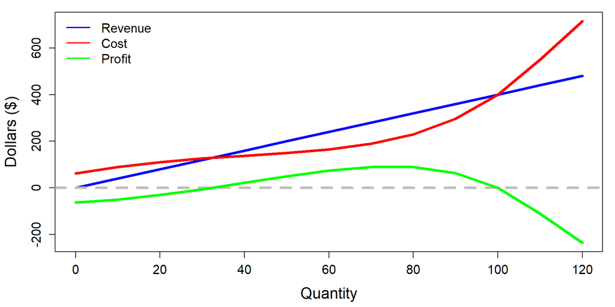

## Perfect Competition

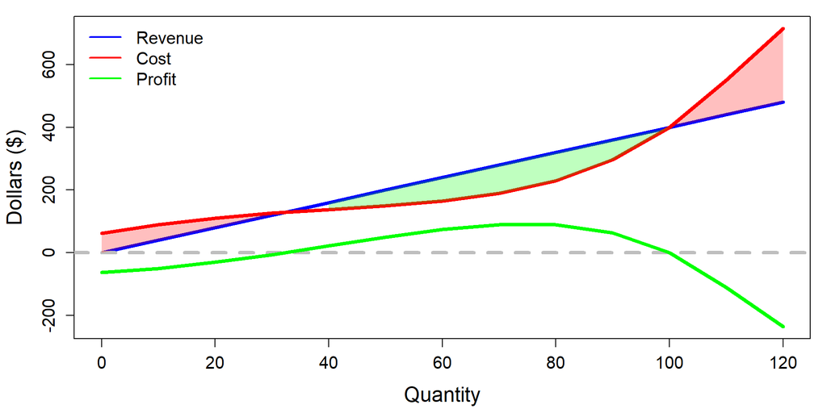

## Perfect Competition

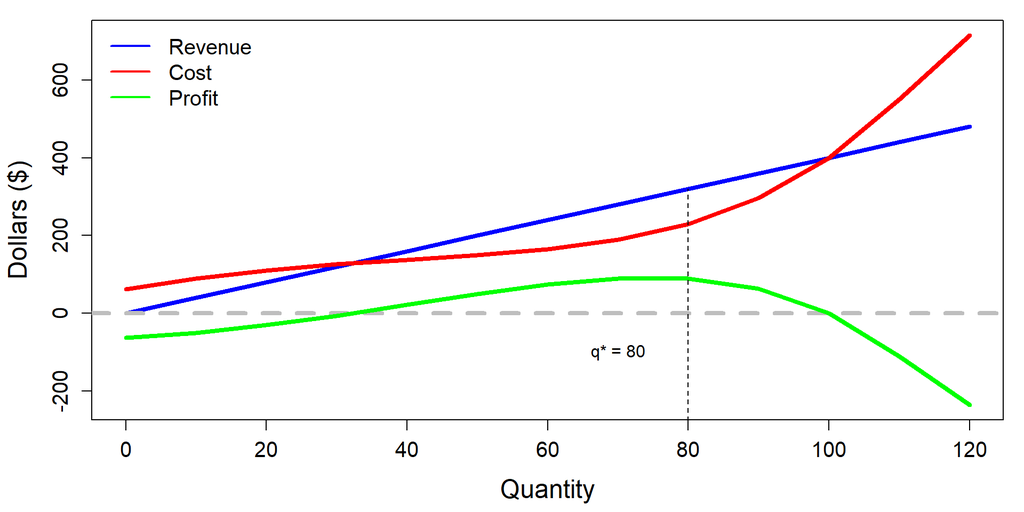

## Perfect Competition

| Q | TR | TC | profit | MR | MC |
| --- | --- | --- | --- | --- | --- |
| 0 | 0 | 62 | -62 |  |  |
| 10 | 40 | 90 | -50 |  |  |
| 20 | 80 | 110 | -30 |  |  |
| 30 | 120 | 126 | -6 |  |  |
| 40 | 160 | 138 | 22 |  |  |
| 50 | 200 | 150 | 50 |  |  |
| 60 | 240 | 165 | 75 |  |  |
| 70 | 280 | 190 | 90 |  |  |
| 80 | 320 | 230 | 90 |  |  |
| 90 | 360 | 296 | 64 |  |  |

## Perfect Competition

| Q | TR | TC | profit | MR | MC |
| --- | --- | --- | --- | --- | --- |
| 0 | 0 | 62 | -62 | NA | NA |
| 10 | 40 | 90 | -50 | 4 | 2.8 |
| 20 | 80 | 110 | -30 | 4 | 2.0 |
| 30 | 120 | 126 | -6 | 4 | 1.6 |
| 40 | 160 | 138 | 22 | 4 | 1.2 |
| 50 | 200 | 150 | 50 | 4 | 1.2 |
| 60 | 240 | 165 | 75 | 4 | 1.5 |
| 70 | 280 | 190 | 90 | 4 | 2.5 |
| 80 | 320 | 230 | 90 | 4 | 4.0 |
| 90 | 360 | 296 | 64 | 4 | 6.6 |

## Perfect Competition

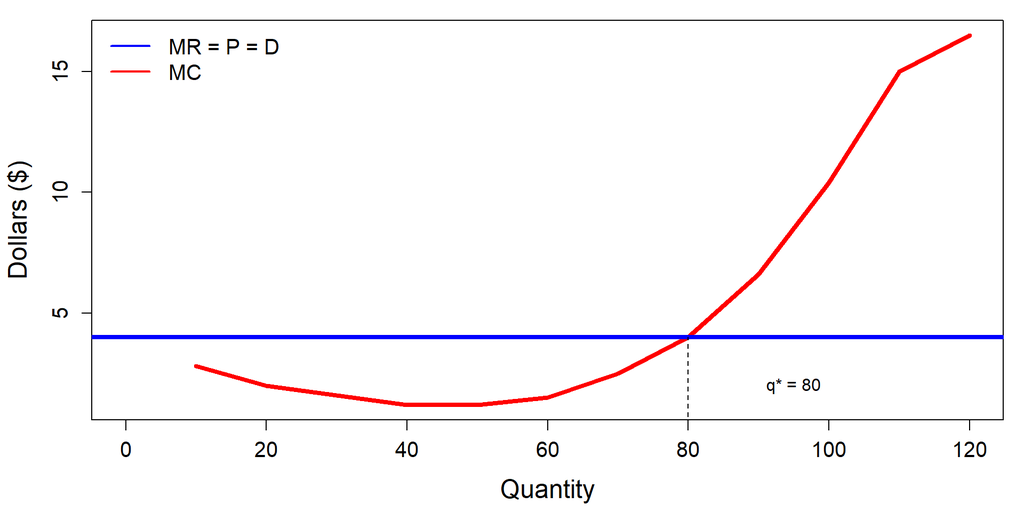

## Perfect Competition

| Q | TR | TC | profit | MR | MC | marginal_profit |
| --- | --- | --- | --- | --- | --- | --- |
| 0 | 0 | 62 | -62 | NA | NA |  |
| 10 | 40 | 90 | -50 | 4 | 2.8 |  |
| 20 | 80 | 110 | -30 | 4 | 2.0 |  |
| 30 | 120 | 126 | -6 | 4 | 1.6 |  |
| 40 | 160 | 138 | 22 | 4 | 1.2 |  |
| 50 | 200 | 150 | 50 | 4 | 1.2 |  |
| 60 | 240 | 165 | 75 | 4 | 1.5 |  |
| 70 | 280 | 190 | 90 | 4 | 2.5 |  |
| 80 | 320 | 230 | 90 | 4 | 4.0 |  |
| 90 | 360 | 296 | 64 | 4 | 6.6 |  |

## Perfect Competition

| Q | TR | TC | profit | MR | MC | marginal_profit |
| --- | --- | --- | --- | --- | --- | --- |
| 0 | 0 | 62 | -62 | NA | NA | NA |
| 10 | 40 | 90 | -50 | 4 | 2.8 | 1.2 |
| 20 | 80 | 110 | -30 | 4 | 2.0 | 2.0 |
| 30 | 120 | 126 | -6 | 4 | 1.6 | 2.4 |
| 40 | 160 | 138 | 22 | 4 | 1.2 | 2.8 |
| 50 | 200 | 150 | 50 | 4 | 1.2 | 2.8 |
| 60 | 240 | 165 | 75 | 4 | 1.5 | 2.5 |
| 70 | 280 | 190 | 90 | 4 | 2.5 | 1.5 |
| 80 | 320 | 230 | 90 | 4 | 4.0 | 0.0 |
| 90 | 360 | 296 | 64 | 4 | 6.6 | -2.6 |

## Perfect Competition

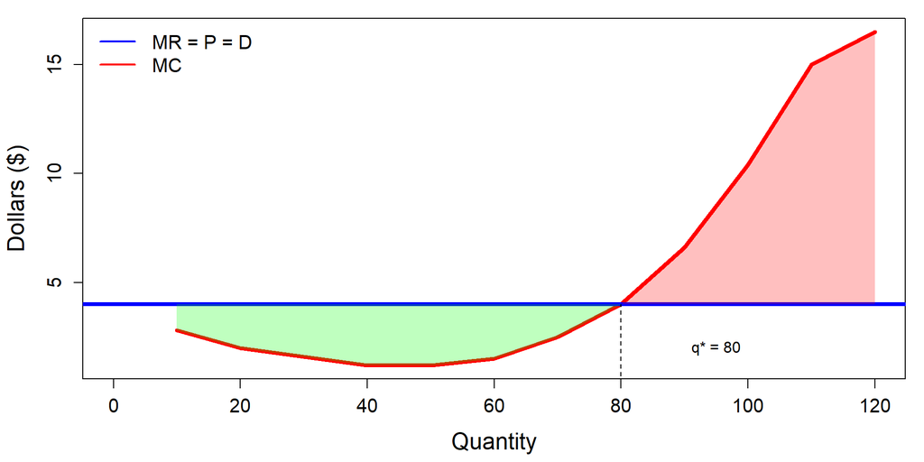

## Perfect Competition

| Q | TR | TC | profit | MR | MC | marginal_profit | AC |
| --- | --- | --- | --- | --- | --- | --- | --- |
| 0 | 0 | 62 | -62 | NA | NA | NA |  |
| 10 | 40 | 90 | -50 | 4 | 2.8 | 1.2 |  |
| 20 | 80 | 110 | -30 | 4 | 2.0 | 2.0 |  |
| 30 | 120 | 126 | -6 | 4 | 1.6 | 2.4 |  |
| 40 | 160 | 138 | 22 | 4 | 1.2 | 2.8 |  |
| 50 | 200 | 150 | 50 | 4 | 1.2 | 2.8 |  |
| 60 | 240 | 165 | 75 | 4 | 1.5 | 2.5 |  |
| 70 | 280 | 190 | 90 | 4 | 2.5 | 1.5 |  |
| 80 | 320 | 230 | 90 | 4 | 4.0 | 0.0 |  |
| 90 | 360 | 296 | 64 | 4 | 6.6 | -2.6 |  |

## Perfect Competition

| Q | TR | TC | profit | MR | MC | marginal_profit | AC |
| --- | --- | --- | --- | --- | --- | --- | --- |
| 0 | 0 | 62 | -62 | NA | NA | NA | NA |
| 10 | 40 | 90 | -50 | 4 | 2.8 | 1.2 | 9.00 |
| 20 | 80 | 110 | -30 | 4 | 2.0 | 2.0 | 5.50 |
| 30 | 120 | 126 | -6 | 4 | 1.6 | 2.4 | 4.20 |
| 40 | 160 | 138 | 22 | 4 | 1.2 | 2.8 | 3.45 |
| 50 | 200 | 150 | 50 | 4 | 1.2 | 2.8 | 3.00 |
| 60 | 240 | 165 | 75 | 4 | 1.5 | 2.5 | 2.75 |
| 70 | 280 | 190 | 90 | 4 | 2.5 | 1.5 | 2.71 |
| 80 | 320 | 230 | 90 | 4 | 4.0 | 0.0 | 2.88 |
| 90 | 360 | 296 | 64 | 4 | 6.6 | -2.6 | 3.29 |

## Perfect Competition

### Profit

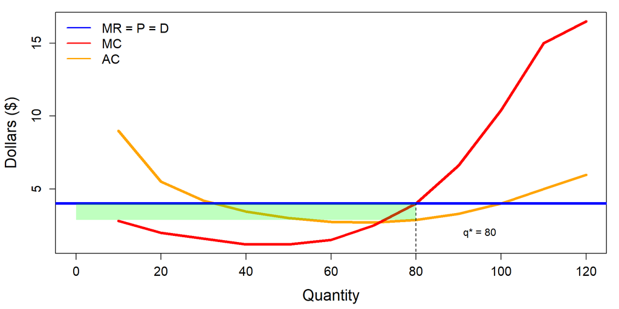

## Perfect Competition

### Break-even

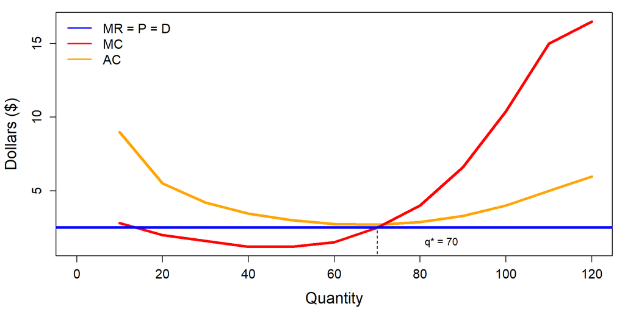

## Perfect Competition

### Loss

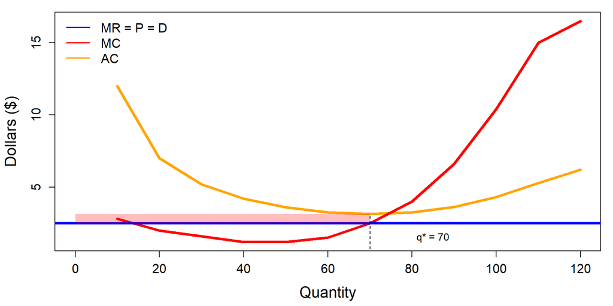

## Perfect Competition

### Entry and Exit

- Firms **enter or exit** the market in response to **profit opportunities**.
- While no individual firm can influence the **market price**, the **collective entry or exit** of many firms affects overall **market supply**.
  - A change in total market supply shifts the **market price**, which in turn alters **profitability** for all firms.

## Perfect Competition

### Long-Run Equilibrium

- When **profits exist**, new firms enter — like **sharks drawn to blood** — increasing market supply and **driving prices down**.
  - This process continues until prices fall to the point where $P = AC \implies \pi = 0$
- In **long-run equilibrium**, no firm has an incentive to enter or exit.
  - All firms earn **zero economic profit** and produce where $P = MR = MC = AC$ since **MC** intersects **AC** at its **minimum point**.

## Perfect Competition

### Long-Run Adjustment

- In the **short run**, firms may earn **profits or losses**.
  - **Profits** attract entry, pushing prices **down** to the zero-profit level.
  - **Losses** lead to exit, reducing supply and pushing prices **up** to the zero-profit level.
- In the **long run**, all firms that remain operate at the **lowest possible cost** with $\pi = 0$ ensuring **no incentive to enter or leave** the market.

## Monopoly

### Introduction

- A **monopoly** is a market with **no competition**, giving the firm substantial **market power**.
  - A single firm produces **all output** in the market.
  - Since it faces **no direct rivals**, it can set prices subject only to the **demand curve**.
- Although a monopoly strictly means one producer, the term is often used more loosely to describe markets dominated by a **single firm with very high market share**.

## Monopoly

### Market Share

- A firm is considered a **monopoly** when it produces a product with **no close substitutes**.
  - If consumers can choose among several **similar alternatives**, even if not identical, the market is **not truly monopolized**.
  - However, determining what counts as a *close substitute* is often **subjective and debated**, making the boundaries of monopoly power **difficult to define in practice**.

## Monopoly

### Barriers to Entry

- Because monopolies face **no competition**, they can earn **sustained economic profits**.
  - In a competitive market, such profits would attract entry—but monopolies persist because of **barriers to entry**.
- **Barriers to entry** are legal, technological, or market conditions that **prevent or discourage potential competitors**.
  - These barriers can range from modest (e.g., **high startup costs**) to extreme (e.g., **exclusive control of scarce resources**).
  - For instance, only a **limited number of radio frequencies** exist; once a firm owns all of them, new entrants are effectively blocked.

## Monopoly

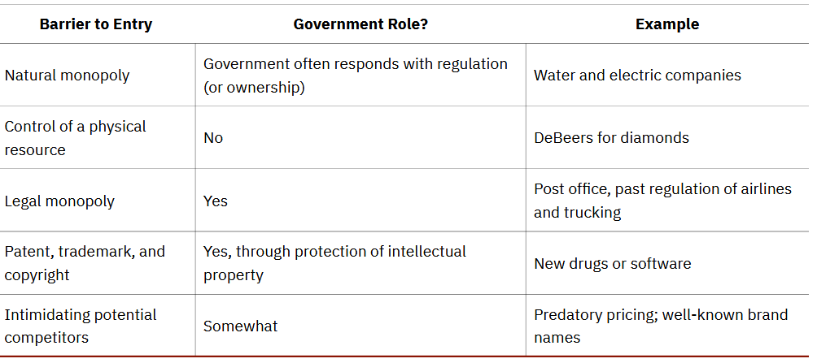

## Monopoly

### Natural Monopoly

- A **natural monopoly** arises when **economies of scale** are large relative to **market demand**.
  - Once the **fixed costs** of infrastructure are in place, the **marginal cost** of serving additional customers is very low.
  - As a result, **one firm** can produce the entire market output **more efficiently** than several smaller firms duplicating investments.

## Monopoly

### Natural Monopoly: Examples

- Once a **water utility** installs main pipes, the cost of connecting one more home is minimal.
- Similarly, after an **electric company** installs lines, serving additional homes is cheap.
- A second firm entering either market would have to duplicate infrastructure—an inefficient use of resources.

## Monopoly

### Local Market Example

- Natural monopolies can also occur in **smaller regional markets** where products are **costly to transport**.
  - For example, **cement plants** experience economies of scale, but **transporting cement** long distances is expensive.
  - In areas without access to water transport, a **single cement plant** may efficiently serve the entire local market.

## Monopoly

### Natural Monopoly

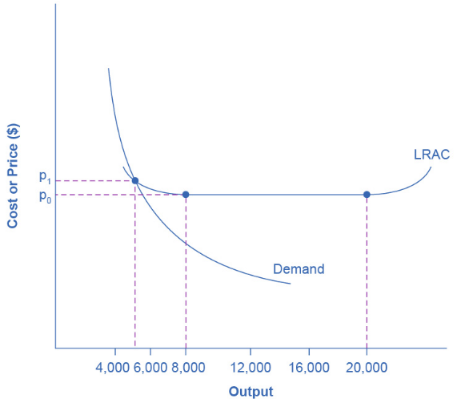

## Monopoly

### Economies of Scale and Market Size

- **Economies of scale** combined with **market size** can naturally restrict competition.
- The long-run average cost (LRAC) curve for airplane manufacturing:
  - Shows **economies of scale** up to about **8,000 planes per year** at price $P_0$
  - Then **constant returns to scale** from 8,000–20,000 planes
  - And **diseconomies of scale** beyond 20,000 planes

## Monopoly

### Natural Monopoly

- The **market demand curve** intersects the LRAC at about **5,000 planes per year** and a price $P_1 > P_0$.
  - This means the market can support only **one efficient producer**.
  - If a second firm entered producing 4,000 planes, its **average cost** would exceed that of the incumbent—making it uncompetitive.
  - If it entered at 8,000 planes to lower costs, it would face **insufficient demand** to sell its output.

## Monopoly

### Promoting Innovation

- Suppose a company invests heavily in research and development and discovers a **cure for the common cold**.
  - In a world where information spreads instantly, other firms could copy the formula and sell the same drug at a lower price—since they didn’t bear the R&D costs.
  - If this happened, few firms would have an incentive to invest in research, leading to **less innovation overall**.
- **Intellectual property law** grants creators temporary or exclusive rights over their ideas, inventions, and brands—providing incentives for innovation while eventually allowing competition.

## Monopoly

### Legal Monopolies & Intellectual Property

- **Patents** give inventors the exclusive right to make, use, or sell an invention (usually **20 years**) so they can recover R&D costs before rivals enter the market.
- **Trademarks** protect distinctive names or symbols that identify products—like **Chiquita**, **Chevrolet**, or the **Nike swoosh**.
- **Copyrights** safeguard original works such as books, music, and art for the **author’s life plus 70 years**.
- **Trade secrets** protect confidential business information—like the **Coca-Cola formula**—without requiring public disclosure.

## Monopoly

### Deregulation

- For decades, some monopolies were **legally protected** due to technological or logistical limits.
  - For example, **AT&T** was once the only company allowed to provide both local and long-distance telephone service.
  - From the 1930s to 1970s, federal regulations also restricted **airline routes and fares**, **bank interest rates**, and **trucking prices**.
  - As technology evolved, these monopolies became harder to justify.

## Monopoly

| q | p | tr | tc |
| --- | --- | --- | --- |
| 0 | 1300 | 0 | 250 |
| 1 | 1200 | 1200 | 500 |
| 2 | 1100 | 2200 | 750 |
| 3 | 1000 | 3000 | 1000 |
| 4 | 900 | 3600 | 1250 |
| 5 | 800 | 4000 | 1650 |
| 6 | 700 | 4200 | 2500 |

## Monopoly

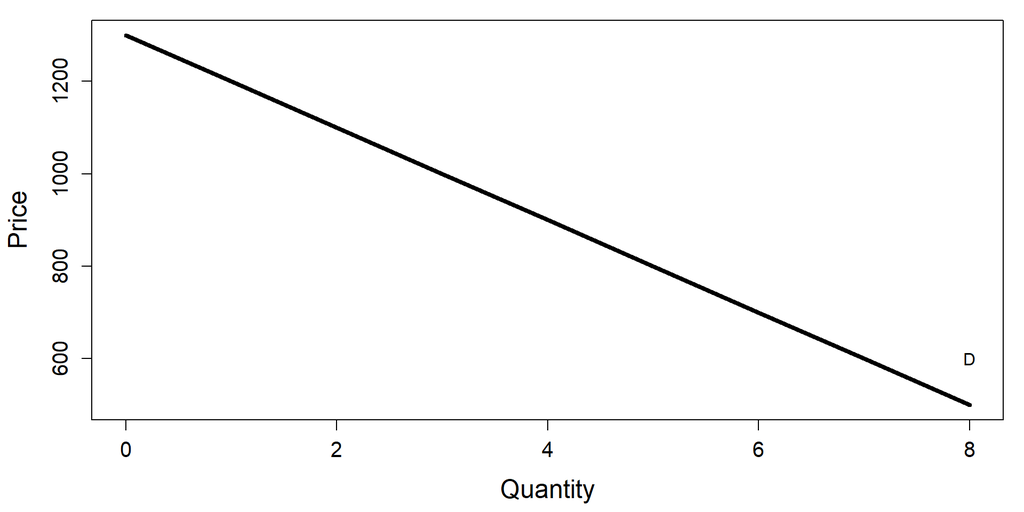

## Monopoly

| q | p | tr | tc | profit |
| --- | --- | --- | --- | --- |
| 0 | 1300 | 0 | 250 | -250 |
| 1 | 1200 | 1200 | 500 | 700 |
| 2 | 1100 | 2200 | 750 | 1450 |
| 3 | 1000 | 3000 | 1000 | 2000 |
| 4 | 900 | 3600 | 1250 | 2350 |
| 5 | 800 | 4000 | 1650 | 2350 |
| 6 | 700 | 4200 | 2500 | 1700 |

## Monopoly

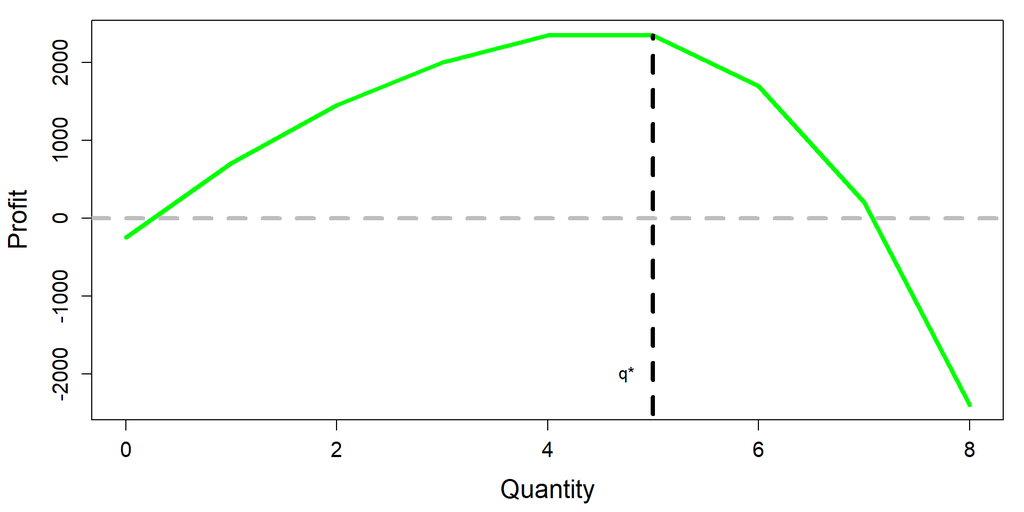

## Monopoly

|  | q | p | tr | tc | profit | mr | mc | ac |
| --- | --- | --- | --- | --- | --- | --- | --- | --- |
| 2 | 1 | 1200 | 1200 | 500 | 700 | 1200 | 250 | 500 |
| 3 | 2 | 1100 | 2200 | 750 | 1450 | 1000 | 250 | 375 |
| 4 | 3 | 1000 | 3000 | 1000 | 2000 | 800 | 250 | 333 |
| 5 | 4 | 900 | 3600 | 1250 | 2350 | 600 | 250 | 312 |
| 6 | 5 | 800 | 4000 | 1650 | 2350 | 400 | 400 | 330 |
| 7 | 6 | 700 | 4200 | 2500 | 1700 | 200 | 850 | 417 |

## Monopoly

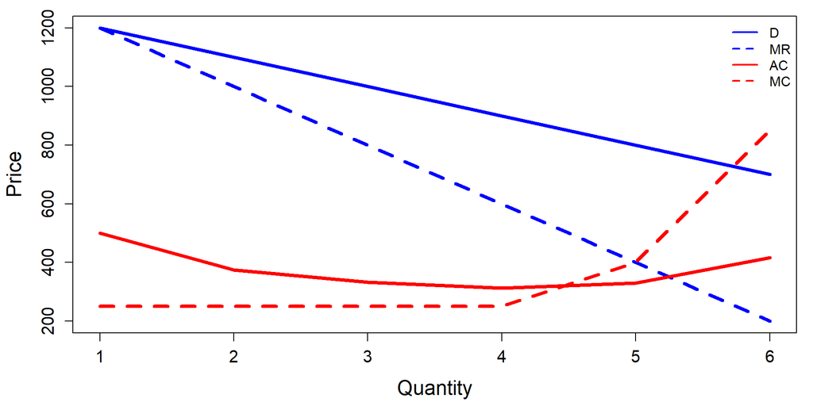

## Monopoly

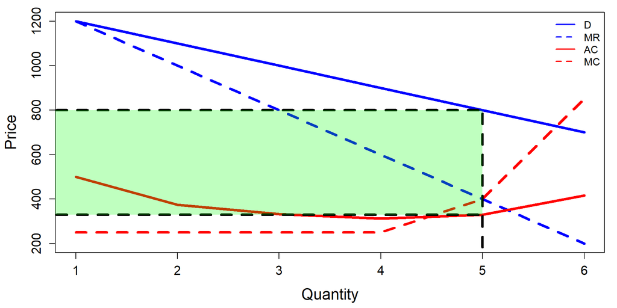

## Monopoly

### Allocative Efficiency

- While monopolies are often criticized for charging **high prices**, economists focus on their failure to produce the **socially optimal quantity** of output.
  - Unlike perfectly competitive markets, monopolies restrict production to maximize profit, leading to **allocative inefficiency**—too little output from society’s perspective.
- Allocative efficiency occurs when the **marginal benefit to society** from one more unit of a good **equals its marginal cost**, ensuring that resources are used where they generate the greatest overall value.

## Imperfect Competition

- Most real-world firms operate **between the extremes** of perfect competition and monopoly.
  - These firms face **some market power** — they can influence the price they charge — but **not complete control**.
- Their behavior depends on how many competitors exist and how differentiated their products are.

## Imperfect Competition

### Monopolistic Competition

- A **monopolistically competitive market** features **many firms** competing to sell products that are **similar but not identical**.
  - Each firm offers a **distinctive product**, giving it some control over price.
  - Examples include clothing retailers, restaurants, grocery stores, or even products like **golf balls** and **beer**, which differ through branding, advertising, and consumer perception.
- Monopolistic competition blends features of both **competition** and **monopoly** - many sellers, but each with a mini-monopoly over its own variety.

## Imperfect Competition

### Oligopoly

- An **oligopoly** is a market dominated by **a small number of large firms**.
  - Example: **Boeing and Airbus** together produce nearly all large commercial aircraft worldwide.
  - Example: The **soft drink industry**, led by **Coca-Cola and Pepsi**.
- Key features:
  - **High barriers to entry**
  - **Strategic interdependence** — firms consider how rivals will react to their output and pricing decisions.

## Imperfect Competition

### Differentiated Products

- **Product differentiation** can occur through:
  - **Physical features:** e.g., *nonstick coating, extra spicy flavor, redesigned for comfort*
  - **Location:** proximity to consumers or key suppliers (e.g., a gas station at a busy intersection)
  - **Intangible aspects:** guarantees, reputation, free delivery, financing options
  - **Perception:** branding and advertising create psychological differences among otherwise similar products

## Imperfect Competition

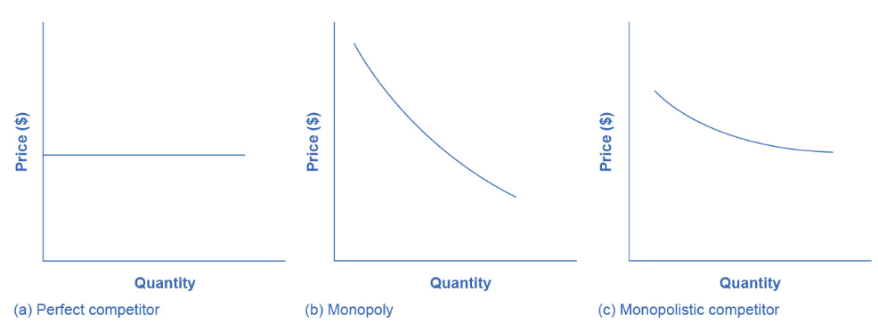

## Imperfect Competition

| q | p | tr | mr | tc | mc | ac |
| --- | --- | --- | --- | --- | --- | --- |
| 10 | 22 | 220 | 22 | 340 | 3.4 | 34.0 |
| 20 | 20 | 400 | 18 | 400 | 6.0 | 20.0 |
| 30 | 18 | 540 | 14 | 480 | 8.0 | 16.0 |
| 40 | 16 | 640 | 10 | 580 | 10.0 | 14.5 |
| 50 | 14 | 700 | 6 | 700 | 12.0 | 14.0 |
| 60 | 12 | 720 | 2 | 840 | 14.0 | 14.0 |
| 70 | 10 | 700 | -2 | 1020 | 18.0 | 14.6 |
| 80 | 8 | 640 | -6 | 1280 | 26.0 | 16.0 |

## Imperfect Competition

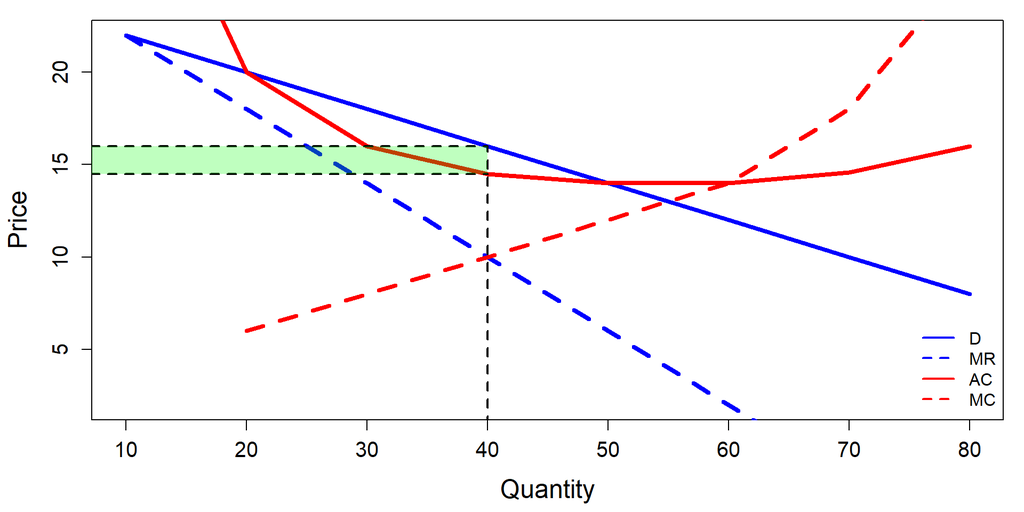

## Imperfect Competition

### Entry and Exit

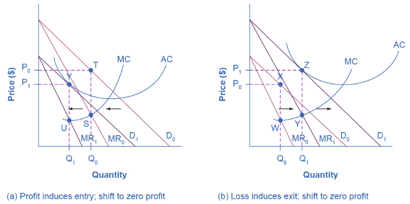

## Imperfect Competition

### Increased Competition (p - 2)

| q | p | tr | mr | tc | mc | ac |
| --- | --- | --- | --- | --- | --- | --- |
| 10 | 20 | 200 | 20 | 340 | 3.4 | 34.0 |
| 20 | 18 | 360 | 16 | 400 | 6.0 | 20.0 |
| 30 | 16 | 480 | 12 | 480 | 8.0 | 16.0 |
| 40 | 14 | 560 | 8 | 580 | 10.0 | 14.5 |
| 50 | 12 | 600 | 4 | 700 | 12.0 | 14.0 |
| 60 | 10 | 600 | 0 | 840 | 14.0 | 14.0 |
| 70 | 8 | 560 | -4 | 1020 | 18.0 | 14.6 |
| 80 | 6 | 480 | -8 | 1280 | 26.0 | 16.0 |

## Imperfect Competition

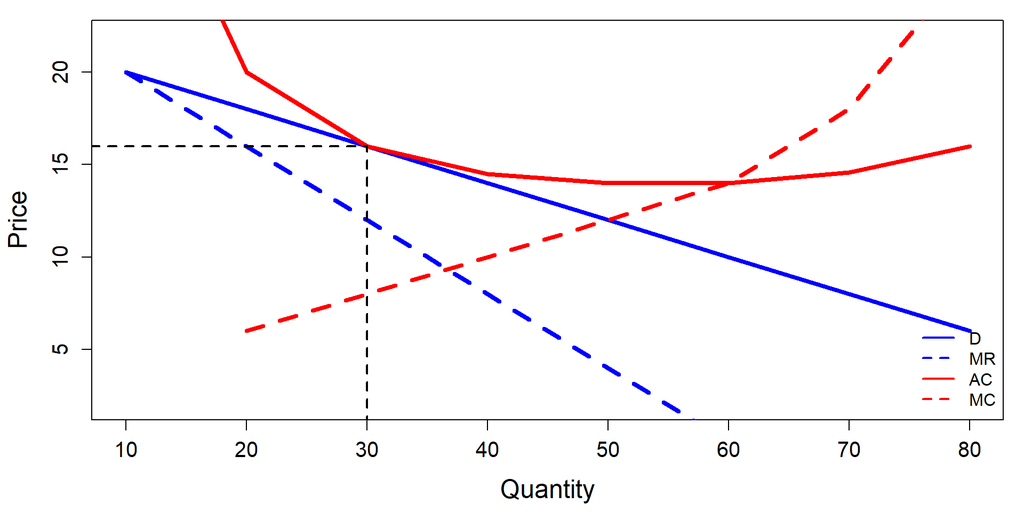

## Imperfect Competition

### Monopolistic Competition and Efficiency

- In **perfect competition**, entry and exit push firms to produce at the **minimum of AC**, achieving **productive efficiency**.
- In **monopolistic competition**, entry and exit lead firms to produce on the **downward-sloping** portion of the AC curve (not at its minimum) so the market is **not productively efficient**.

## Imperfect Competition

### Monopolistic Competition and Efficiency

- Perfectly competitive firms produce where **P = MC**, achieving **allocative efficiency**.
- Monopolistically competitive firms set **MR = MC**, but because demand slopes downward, **P > MR**, meaning **P > MC**.
  - When **P > MC**, society values extra units more than they cost to produce, but the firm does not supply them.
  - The result is **allocative inefficiency** – a higher price and lower quantity than under perfect competition.

## Imperfect Competition

### Benefits of Variety and Differentiation

- Although monopolistic competition lacks productive and allocative efficiency, it provides **variety**.
  - Consumers prefer differentiated options (different clothes, foods, services, and product features) over the uniformity implied by perfect competition.
  - Firms compete through service, quality, features, and innovation.

## Imperfect Competition

### Benefits of Variety and Differentiation

- Debate persists over whether markets create **too much** or the **right amount** of variety.
  - Critics argue that extensive differentiation and advertising can be **socially wasteful**.
  - Defenders argue that consumers **choose variety**, and firms’ pursuit of profit drives meaningful innovation and choice.
- The “optimal” amount of variety is hard to define and depends on how one values consumer choice.

## Imperfect Competition

### Oligopoly

- Oligopoly firms face a strong temptation to act like a **monopoly**.
  - By coordinating, they can restrict output, raise prices, and share the resulting profits.
  - Such coordinated behavior is called **collusion**.
- A formal collusive agreement to set output and price like a monopoly is known as a **cartel**.

## Imperfect Competition

### Game Theory

- Oligopolies are **mutually interdependent**, so no single unified theory predicts their behavior.
- Economists instead use **game theory**, which studies strategic decision-making where payoffs depend on others’ actions.
  - Game theory has broad applications in economics, business, law, and military strategy.

## Imperfect Competition

### Prisoner’s Dilemma

- The **prisoner’s dilemma** illustrates situations where cooperation yields higher gains than acting in self-interest.
  - It maps well onto oligopoly: firms would benefit from cooperating, but each has an incentive to cheat.
- The term comes from a classic scenario in economics and the social sciences, referring to scenarios where individuals are “prisoner” to their own best strategy.

## Imperfect Competition

### Prisoner’s Dilemma

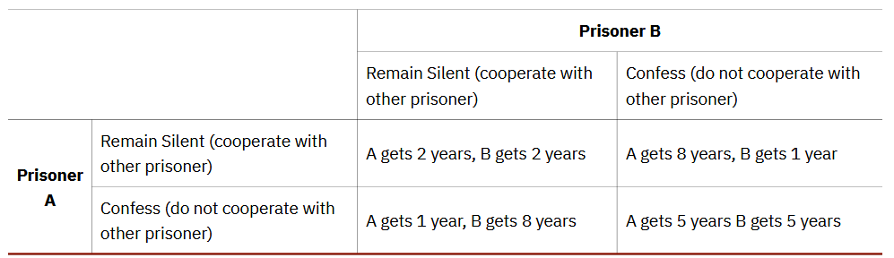

## Imperfect Competition

### Prisoner’s Dilemma

|  |  | Player B |  |
| --- | --- | --- | --- |
|  |  | Collude | Compete |
| Player A | Collude | ($1,000, $1000) | ($200, $1,500) |
|  | Compete | ($1,500, $200) | ($400, $400) |

## Imperfect Competition

### Oligopoly

- When Oligopoly arises from **innovation** or **economies of scale**, it can benefit consumers by lowering costs or improving products.
- However, strong **barriers to entry** allow oligopolists to earn long-run profits and reduce pressure to innovate or provide high-quality service.
  - Oligopolists also tend not to produce at the **minimum of AC**.
- The goal of eocnomic policy is to balance these realities.